# cmsc320final

Govind Nair

5/16/2020

In this tutorial, we will be analyzing data on the number of cases and deaths due to COVID-19 across different countries in the world using concepts in data science.

From differential equations, we know that populations grow according to a logistic model: exponentially increasing initially, and then plateauing towards a certain limit. COVID-19 can be thought of as a population of viruses that grow in the same manner. Our task is to see whether COVID-19 does in fact follow the logistic curve, what factors go into infection rate and death rate, and to see what predictions we can make from the information we have.

For more on logistic curves: https://study.com/academy/lesson/logistic-population-growth-equation-definition-graph.html

The first step in our analysis is to gather some data that can be used for the task.

```r
covid_df <- read.csv("owid-covid-data.csv")
head(covid_df %>% sample_frac(0.1))
```

```
##   iso_code location       date total_cases new_cases total_deaths new_deaths
## 1      NOR   Norway 2020-03-17        1169        92            3          2
## 2      IND    India 2020-03-14          83         8            2          1
## 3      MAR  Morocco 2020-04-12        1545        97          111          4
## 4      GEO  Georgia 2020-05-01         539        22            6          0
## 5      POL   Poland 2020-03-25         901       152           10          2
## 6      YEM    Yemen 2020-05-01           6         0            2          2
##   total_cases_per_million new_cases_per_million total_deaths_per_million
## 1                 215.633                16.970                    0.553
## 2                   0.060                 0.006                    0.001
## 3                  41.858                 2.628                    3.007
## 4                 135.116                 5.515                    1.504
## 5                  23.807                 4.016                    0.264
## 6                   0.201                 0.000                    0.067
##   new_deaths_per_million total_tests new_tests total_tests_per_thousand
```

[output cut: 34 more lines]

The data table above is downloaded from https://ourworldindata.org/. A small sample of the full data set is shown above. The full data set has 17635 entities (or rows), each with 29 attributes (or columns). In our experiment, entities can be thought of as observations, and attributes are the characteristics of each entity. Each entity can be uniquely identified by its iso_code and date, therefore, in our experiment, the pair (iso_code, date) is called a superkey. Since our superkey is minimal (has the fewest possible number of attributes), it is also a candidate key. Since we will use this key to uniquely identify entities, our candidate key is also a primary key.

Data is not always organized nicely. When gathering data off of websites, CSS selectors can be used to select html nodes and tables off of websites and organize the data in to a data table. A data table organized as entities with attributes is called a data frame.

Often, data frames are not “tidy” either, meaning the data frame does not properly organize entities and attributes. This has to be manually organized in order to properly analyze the data.

Sometimes, missing data in data frames are not encoded correctly as NA, this too has to be corrected manually by changing all incorrectly encoded missing data as NA.

Sometimes data from two or more sources are used to perform analysis. In this case, some entities are repeated across data sets with slightly different attributes. We can combine such entities into one using a similiarity function. A similarity function takes as input attributes of two entities and outputs a scalar indicating how similar these entities are. If two entities have a large enough similarity, they can be considered to be the same entity. Similarly, we can also define a dissimilarity function which tells us how dissimilar two entities are. If two entities have a small enough dissimilarity, they can be considered to be the same entity.

Attributes in a data frame might also not have the correct type, for example, an integer might be represented as a string. To make analysis easier, we change the incorrect types in to desired types. In our experiment, we will change the type of iso_code and location from factors to characters, and date from factor to dates. We will also remove attributes from our data frame which we do not intend on using for our analysis or can be recovered using other attributes.

For more on data types: https://en.wikipedia.org/wiki/Data_type

```r
covid_df$iso_code <- as.character(covid_df$iso_code)
covid_df$location <- as.character(covid_df$location)
covid_df$date <- as.Date(covid_df$date)
covid_df <- covid_df %>%
  subset(select = c(iso_code, location, date, total_cases, total_deaths, population, median_age,
                    gdp_per_capita, diabetes_prevalence, female_smokers, male_smokers, handwashing_facilities))

head(covid_df %>% sample_frac(0.1))
```

```
##   iso_code                     location       date total_cases total_deaths
## 1      ITA                        Italy 2020-05-13      221216        30911
## 2      ECU                      Ecuador 2020-02-03           0            0
## 3      EST                      Estonia 2020-04-12        1304           24
## 4      COD Democratic Republic of Congo 2020-04-30         500           31
## 5      SWE                       Sweden 2020-01-17           0            0
## 6      HRV                      Croatia 2020-04-06        1182           15
##   population median_age gdp_per_capita diabetes_prevalence female_smokers
## 1   60461828       47.9      35220.084                4.78           19.8
## 2   17643060       28.1      10581.936                5.55            2.0
## 3    1326539       42.7      29481.252                4.02           24.5
## 4   89561404       17.0        808.133                6.10             NA
## 5   10099270       41.0      46949.283                4.79           18.8
## 6    4105268       44.0      22669.797                5.59           34.3
##   male_smokers handwashing_facilities
## 1         27.8                     NA
## 2         12.3                 80.635
## 3         39.3                     NA
## 4           NA                  4.472
## 5         18.9                     NA
## 6         39.9                     NA
```

We changed the types of columns iso_code, location, and date from factors to characters, characters, and dates respectively. Now our data frame is ready to analyze. Note: The two data frames shown appear not to have the same entities; this is because only a small RANDOM sample of the entire data frame is shown in each.

We also extracted a subset of attributes that we plan on using, namely: iso_code, location, date, total_cases, total_deaths, population, median_age, gdp_per_capita, diabetes_prevalence, female_smokers, male_smokers, and handwashing_facilities. Now we have the same number of entities, but only 12 attributes.

Now we perform some exploratory data analysis (EDA). This is the final step before we start modeling using statistics and/or machine learning.

EDA is simply a way of better understanding the data at hand, often this can be done through visualization. As an initial step, let’s take a look at how the total number of COVID-19 cases changes over time.

For more on EDA: https://en.wikipedia.org/wiki/Exploratory_data_analysis

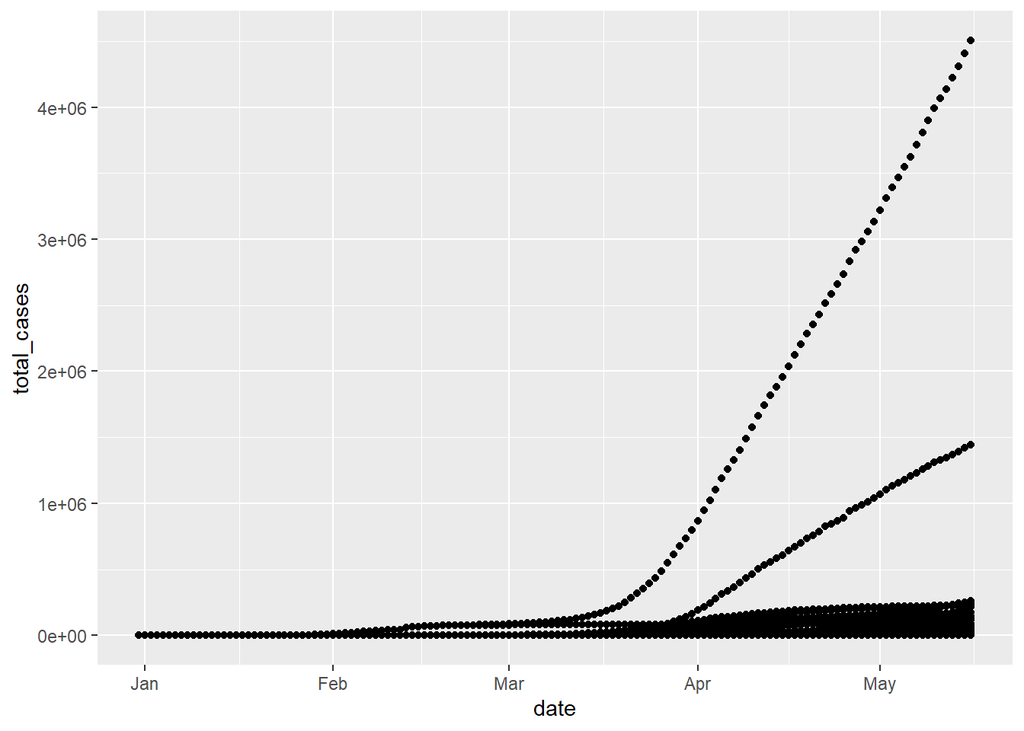

```r
covid_df %>%
  ggplot(mapping = aes(x = date, y = total_cases)) +
  geom_point()
```

Here we see three drastically different trends in our data, analogous to three separate functions of time. Let’s see if the total deaths also follow similar trends.

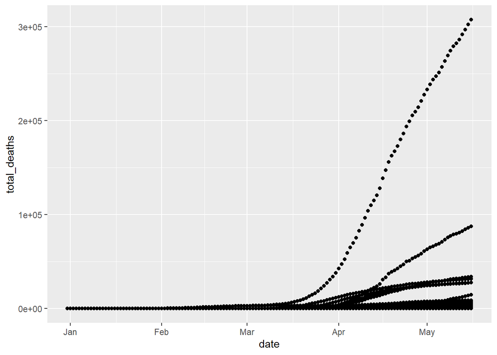

```r
covid_df %>%
  ggplot(mapping = aes(x = date, y = total_deaths)) +
  geom_point()
```

The data appears similar, so let’s map both total cases and deaths over time, encoding deaths as the color of each point.

Hypothesizing that the population of the virus grows according to a logistic curve, so far it appears as if the population has not hit its inflection point and started plateauing yet, it is still hypothesized to be growing exponentially. Therefore, we will plot the log of total cases and see if it appears to be linear.

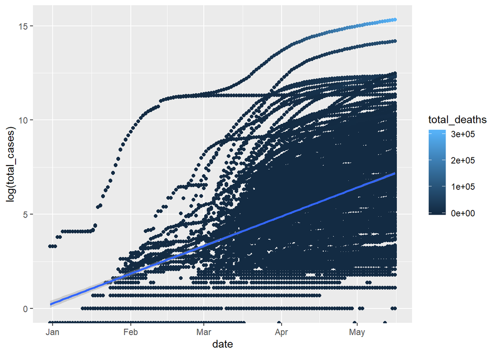

```r
covid_df %>%
  ggplot(mapping = aes(x = date, y = log(total_cases), color = total_deaths)) +
  geom_point() +
  geom_smooth(method = lm)
```

Now we hypothesize that total cases and deaths follow a similar trend, lets see if we can visualize this by plotting total deaths vs total cases. We expect a linear model.

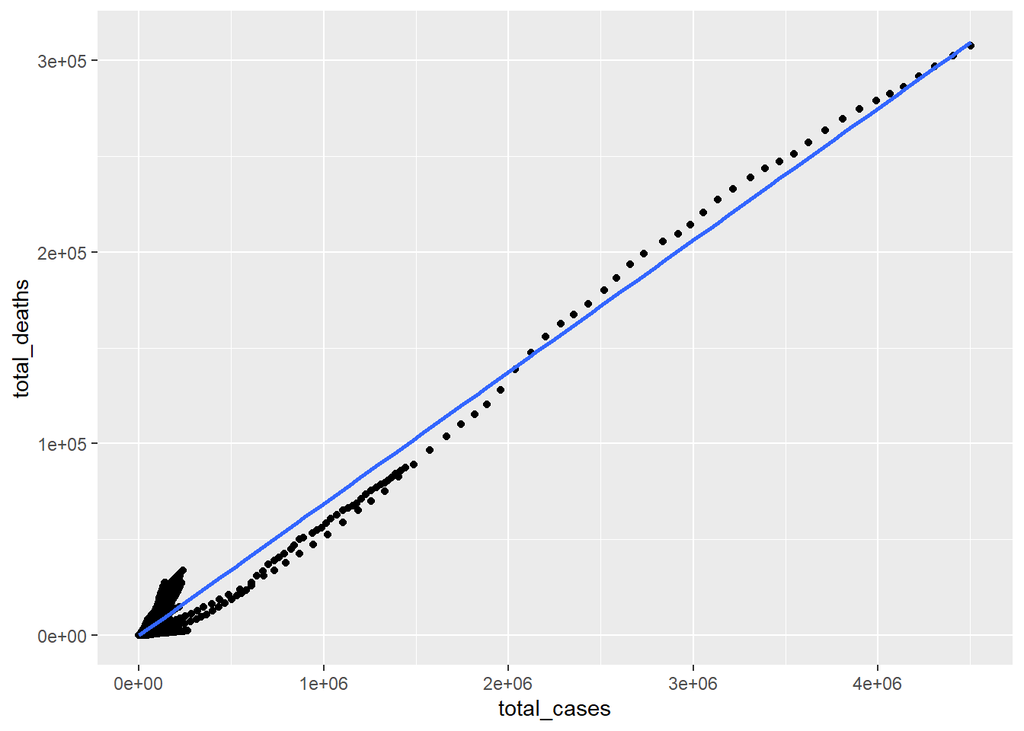

```r
covid_df %>%
  ggplot(aes(x = total_cases, y = total_deaths)) +
  geom_point() +
  geom_smooth(method = lm)
```

Now, since we see a cluster on the bottom left corner of our plot, and only few data points as total cases increases, we want the data to uniformly take up space on our plot, meaning we want to spread the data out evenly. Lets try taking the log of both variables and see if we can spread out the data points more evenly.

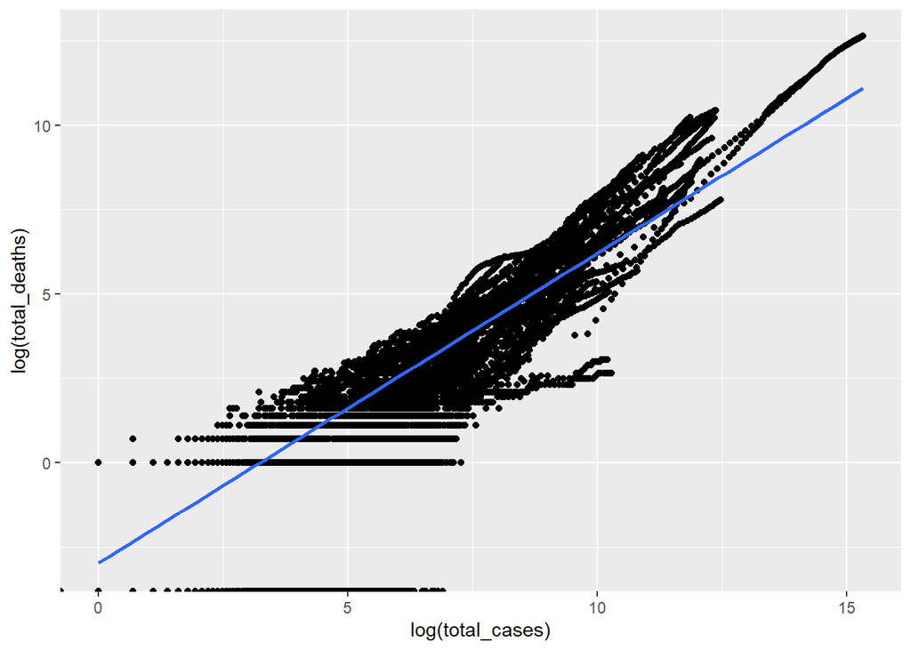

```r
covid_df %>%
  ggplot(aes(x = log(total_cases), y = log(total_deaths))) +
  geom_point() +
  geom_smooth(method = lm)
```

Here we plot the log of both axes, which brings larger values closer to smaller values. We do appear to have a large cluster still, but it separates most of the data points from points that appear to be outliers. This plot however ommits entities that have 0 total deaths and/or 0 total cases since log(0) is negative infinity, so we are missing a large chunk of data on this plot, around 8000 entities are ommitted.

It appears as if total cases and deaths do follow a similar trend, so total cases can be used to predict total deaths. Using statistics, we can check to see if there is a statistically significant linear relationship between total cases and deaths.

```r
casesVdeaths <- lm(total_deaths ~ total_cases, data = covid_df)
casesVdeathsStats <- tidy(casesVdeaths)
casesVdeathsStats
```

```
## # A tibble: 2 x 5
##   term        estimate  std.error statistic p.value
##   <chr>          <dbl>      <dbl>     <dbl>   <dbl>
## 1 (Intercept) -34.3    12.0           -2.85 0.00433
## 2 total_cases   0.0687  0.0000773    889.   0
```

Since the p value for the slope of total cases is less than 0.01 (we will use alpha = 0.01), it is safe to say that there is a linear relationship between total cases and deaths. Therefore, we will focus on cases and we can predict deaths using this model if needed.

What we just did was hypothesis testing. What the table above says is: Assuming there is no linear relationship between total cases and deaths (coefficient of total cases in total deaths = 0.068731 * total cases - 34.302301 is actually 0), there is a 0.000000000 probability that we get the graph above. Note: A statistically significant relationship between two variables implies a statistically significant relationship between the log of both the variables since the exponential of the log of both the variables gives back the original equation. Note: A linear model can be a function of multiple predictor variables each with their own slope which may or may not be statistically significant.

For more on hypothesis testing: https://www.statisticshowto.com/probability-and-statistics/hypothesis-testing/

Let’s continue with some more EDA and compute some summary statistics of our data to get a better idea of how it is distributed.

```r
covid_df %>%
  summarize(min_cases = min(total_cases), max_cases = max(total_cases),
            mean_cases = mean(total_cases), median_cases = median(total_cases))
```

```
##   min_cases max_cases mean_cases median_cases
## 1         0   4503836   14923.94           67
```

Since the mean of the number of cases is much larger than the median, we know that the total number of cases is skewed to the right with the majority of values on the left and with a few values on the right.

Lets see if we can visualize this. Since the data is skewed to the right, we will use a logarithmic scale to better show the distribution of total cases.

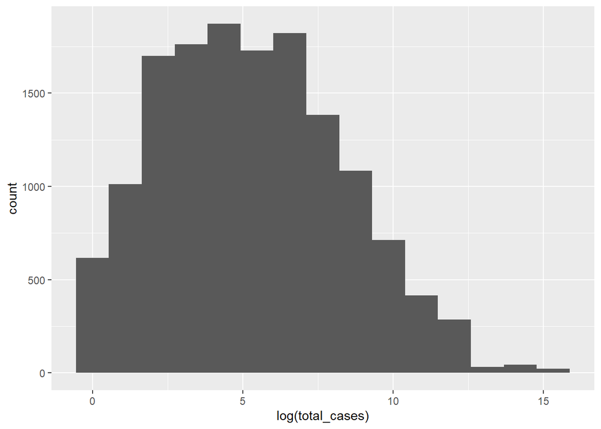

```r
covid_df %>%
  ggplot(aes(x = log(total_cases))) +
  geom_histogram(bins = 15)
```

The histogram shows what we expected, the data is skewed to the right with majority of data points on the left.

Now lets see if any other variables, such as gdp, median age, and hand washing facilities, can be predicted using total cases. Just like we did with total deaths, we will create three plots, and then see if each of them is a statistically significant linear model.

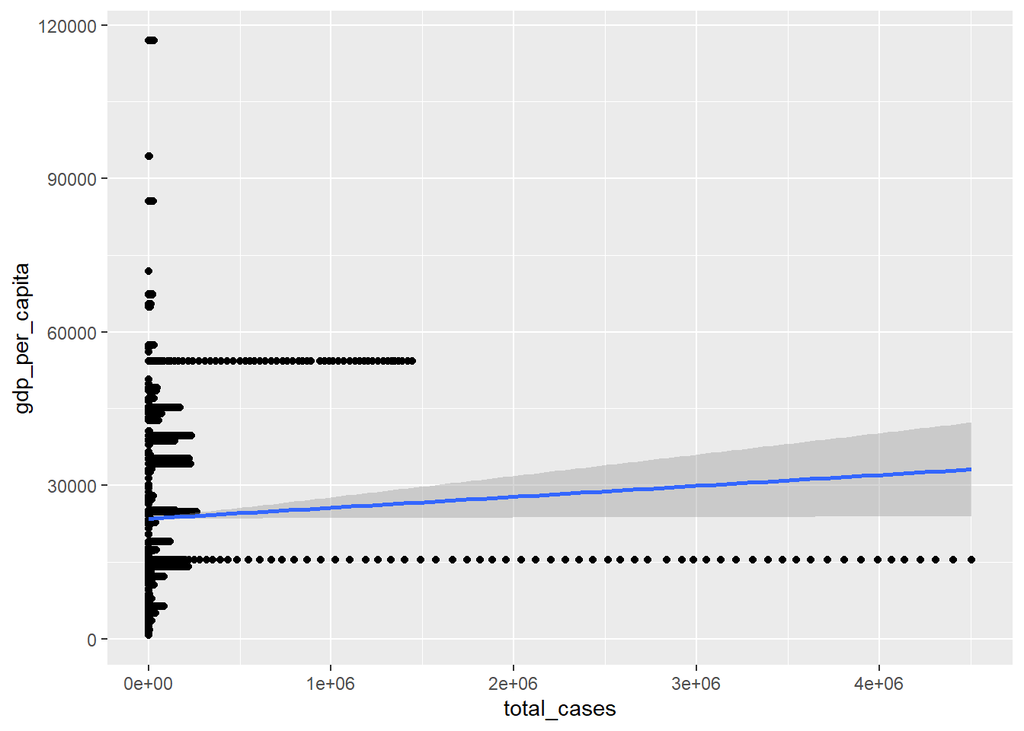

```r
covid_df %>%
  ggplot(aes(x = total_cases, y = gdp_per_capita)) +
  geom_point() +
  geom_smooth(method = lm)
```

There does not appear to be a linear relationship between gdp and total cases. Let’s quantify this statement.

```r
gdpVcases <- lm(gdp_per_capita ~ total_cases, data = covid_df)
tidy(gdpVcases)
```

```
## # A tibble: 2 x 5
##   term           estimate std.error statistic p.value
##   <chr>             <dbl>     <dbl>     <dbl>   <dbl>
## 1 (Intercept) 23522.      171.         137.    0
## 2 total_cases     0.00214   0.00105      2.04  0.0411
```

Since p value = 0.04108769 > alpha = 0.01, there is no significant relationship between gdp and total cases.

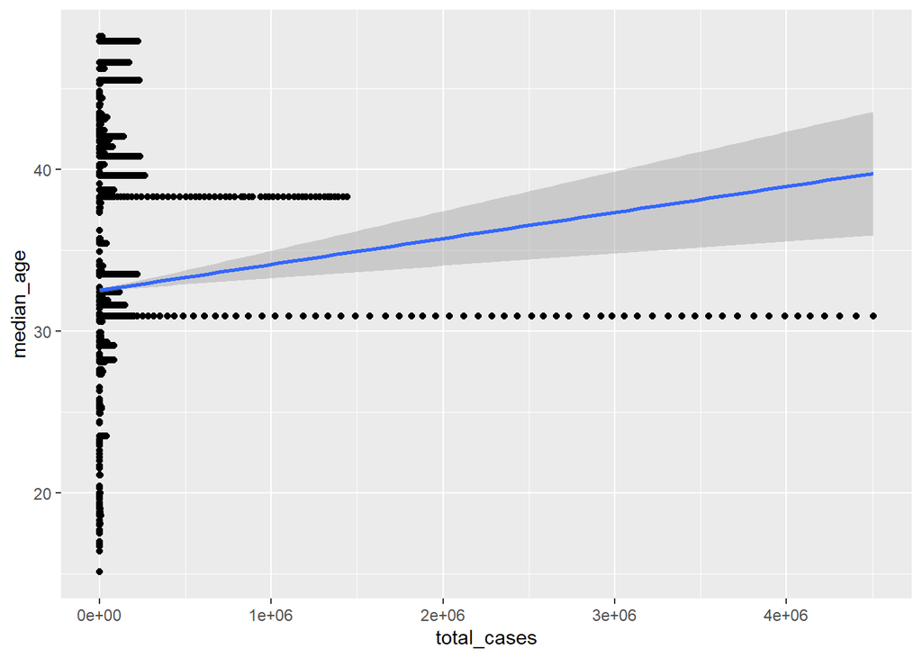

```r
covid_df %>%
  ggplot(aes(x = total_cases, y = median_age)) +
  geom_point() +
  geom_smooth(method = lm)
```

There doesn’t appear to be a linear relationship between total cases and median age.

```r
ageVcases <- lm(median_age ~ total_cases, data = covid_df)
tidy(ageVcases)
```

```
## # A tibble: 2 x 5
##   term           estimate   std.error statistic  p.value
##   <chr>             <dbl>       <dbl>     <dbl>    <dbl>
## 1 (Intercept) 32.5        0.0705         461.   0
## 2 total_cases  0.00000161 0.000000433      3.71 0.000208
```

However, there is a statistically significant linear relationship between median age and total cases. This discrepancy between what we expect from the plot and what hypothesis testing tells us could be a fault of the model we are using.

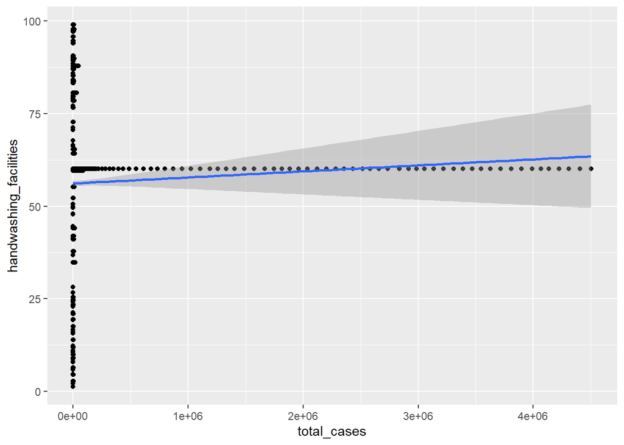

```r
covid_df %>%
  ggplot(aes(x = total_cases, y = handwashing_facilities)) +
  geom_point() +
  geom_smooth(method = lm)
```

There doesn’t appear to be a linear relationship between total cases and handwashing facilities.

```r
handwashingVcases <- lm(handwashing_facilities ~ total_cases, data = covid_df)
tidy(handwashingVcases)
```

```
## # A tibble: 2 x 5
##   term           estimate  std.error statistic p.value
##   <chr>             <dbl>      <dbl>     <dbl>   <dbl>
## 1 (Intercept) 56.1        0.372         151.     0
## 2 total_cases  0.00000163 0.00000159      1.03   0.305
```

Since p value = 0.3051465 > alpha = 0.01, there is no statistically significant linear relationship between total cases and handwashing facilities.

Now we will see if we can predict the total cases for future dates using the data we have. We will compare four different models: linear model, logistic model, decision tree model, and random forest model using 10 fold cross validation, and use the best model to predict the growth of the virus population for future dates.

A linear model will be of the form y = ax + b, where y is the variable we are trying to predict, x is the variable we are using to predict y, and a and b are constants.

For more on linear regression: http://www.stat.yale.edu/Courses/1997-98/101/linreg.htm

A logistic model is is a linear model predicting the log of the odds of an event, where the odds of an event is the probability that the ratio of the probability of an event and the probability of the event’s complement.

For more on logistic regression: https://towardsdatascience.com/logistic-regression-detailed-overview-46c4da4303bc

A decision tree model can be thought of as a binary tree with predicates at each non-terminal node and predictions at each leaf node. At each non terminal node, depending of whether the predicate at the node is true or false, we pick either the left or right child node to visit next and continue until we reach a leaf node prediction.

For more on binary trees: https://en.wikipedia.org/wiki/Binary_tree For more on decision trees: https://en.wikipedia.org/wiki/Decision_tree

A random forest model is a collection of decision trees, each made using a random sample (with replacement) of the data at hand. The resulting prediction is the mean of the predictions from all the decision trees in the random forest.

For more on random forests: https://www.stat.berkeley.edu/~breiman/RandomForests/cc_home.htm

Since we are predicting for future dates, this is the only predictor variable we will be using.

```r
linear <- lm(total_cases ~ date, data = covid_df)
logistic <- glm(total_cases ~ date, data = covid_df)
treeM <- tree(total_cases ~ date, data = covid_df)
rf <- randomForest(total_cases ~ date, data = covid_df)
```

Having our four models defined, lets use 10 fold cross validation to see which model performs best at predicting. k-fold cross validation is done by splitting the data into k subsets, and then for each of the subsets we build a model using the other k-1 subsets, and then we see how good the model does at predicting the excluded subset. In our case, we use k = 10.

For more on k-fold cross validation: https://machinelearningmastery.com/k-fold-cross-validation/

```r
get_error <- function(training_set, validation_set, model){
  if (model=="tree"){
    model <- tree(total_cases~date, data=covid_df)
  }
  else if (model=="linear"){
    model <- lm(total_cases~date, data=covid_df)
  }
  else if (model=="logistic"){
    model <- glm(total_cases~date, data=covid_df)
  }
  else{
    model <- randomForest(total_cases~date, data=covid_df)
  }
  empty_validation_set <- validation_set %>%
    mutate(total_cases=NA)
  preds <- predict(model, empty_validation_set)

  mse <- (sum(preds - validation_set$total_cases))^2 / nrow(validation_set)
  return(mse)
}

errs <- data.frame(method=NA, err=NA)

k <- 10
fold_indices <- cvFolds(n=nrow(covid_df), K=k)

for(i in 1:k){
  validate_indices <- which(fold_indices$which==i)
  training_set <- covid_df[-validate_indices,]
  validation_set <- covid_df[validate_indices,]

  tree_err <- get_error(training_set, validation_set, "tree")
  forest_err <- get_error(training_set, validation_set, "randomForest")
  linear_err <- get_error(training_set, validation_set, "linear")
  logistic_err <- get_error(training_set, validation_set, "logisitic")
  df <- data.frame(method="tree", err=tree_err) %>%
    rbind(data.frame(method="forest", err=forest_err)) %>%
    rbind(data.frame(method="linear", err=linear_err)) %>%
    rbind(data.frame(method="logistic", err=logistic_err))
  errs <- errs %>%
    rbind(df)
}
```

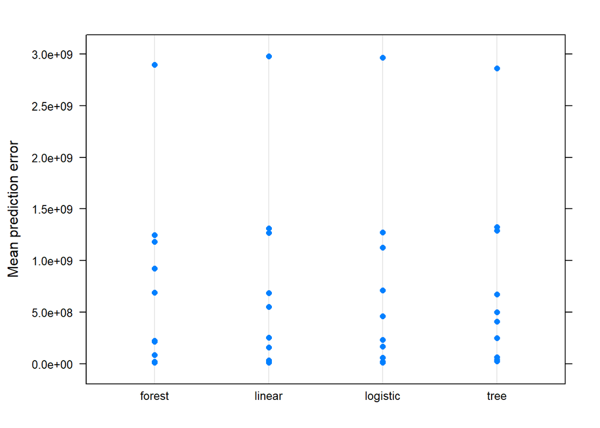

```r
dotplot(err~method, data=errs, ylab="Mean prediction error")
```

Here we calculate how well a model does by calculating the mean squared error (MSE) of the predictions when using each model, the mean of (prediction - actual value)^2. Plotting the MSEs for each of the 10 subsets for each of the model shows us that all models appear to perform equally well, therefore, we will use the model with the smallest mean MSE.

```r
linearErrs <- errs %>%
  filter(method=="linear")
logErrs <- errs %>%
  filter(method=="logistic")
treeErrs <- errs %>%
  filter(method=="tree")
rfErrs <- errs %>%
  filter(method=="forest")
df <- data.frame(linear=mean(linearErrs$err), logistic=mean(logErrs$err), tree=mean(treeErrs$err), rf=mean(rfErrs$err))
df
```

```
##      linear  logistic      tree        rf
## 1 728114939 701673604 743097133 748928435
```

The data table shows that the mean MSE for each model, we will use the model with the least mean MSE to predict for the future. Note: Mean MSE will be different each time we perform this experiment due to the randomness in k-fold cross validation, therefore the model with the least mean MSE will be different in each experiment.

Our data set contains data from December 31 2019 to May 16 2020, we will predict the total cases for all days for the rest of the year 2020.

```r
model <- NA
if(df[1, "linear"] < df[1, "logistic"] & df[1, "linear"] < df[1, "tree"] & df[1, "linear"] < df[1, "rf"]){
  model <- linear
}else if(df[1, "logistic"] < df[1, "linear"] & df[1, "logistic"] < df[1, "tree"] & df[1, "logistic"] < df[1, "rf"]){
  model <- logistic
}else if(df[1, "tree"] < df[1, "linear"] & df[1, "tree"] < df[1, "logistic"] & df[1, "tree"] < df[1, "rf"]){
  model <- tree
}else{
  model <- rf
}
dates <- seq(as.Date("2020-5-17"), as.Date("2020-12-31"), by = "days")

to_predict <- data.frame(date = dates, total_cases = NA)

predictions <- predict(model, to_predict)
head(predictions)
```

```
##        1        2        3        4        5        6
## 31496.28 31819.83 32143.38 32466.93 32790.48 33114.03
```

These are the predictions for the total number of cases for some of the days we want to predict. Let’s combine this data with our original data and plot it to get a visual sense of how well we have predicted the data.

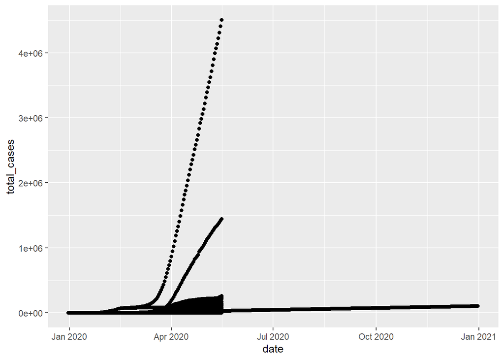

```r
predicted_df <- to_predict %>%
  mutate(total_cases = predictions, iso_code = NA, location = NA, total_deaths = NA, population = NA,
         median_age = NA, gdp_per_capita = NA, diabetes_prevalence = NA, female_smokers = NA,
         male_smokers = NA, handwashing_facilities = NA)

new_df <- covid_df %>%
  rbind(predicted_df)

new_df %>%
  ggplot(aes(x = date, y = total_cases)) +
  geom_point()
```

Our predictions follow one of the three trends we initially saw in our data set, so it seems to be an acceptable set of predictions. We might have expected the data to follow one of the other two trends, but since the density of points is highest on the trend where total cases are the least, these data points influence our trained model more than the other two trends.

Let’s isolate the trend with the greatest density and see whether this curve specifically does follow a logistic curve as initially hypothesized.

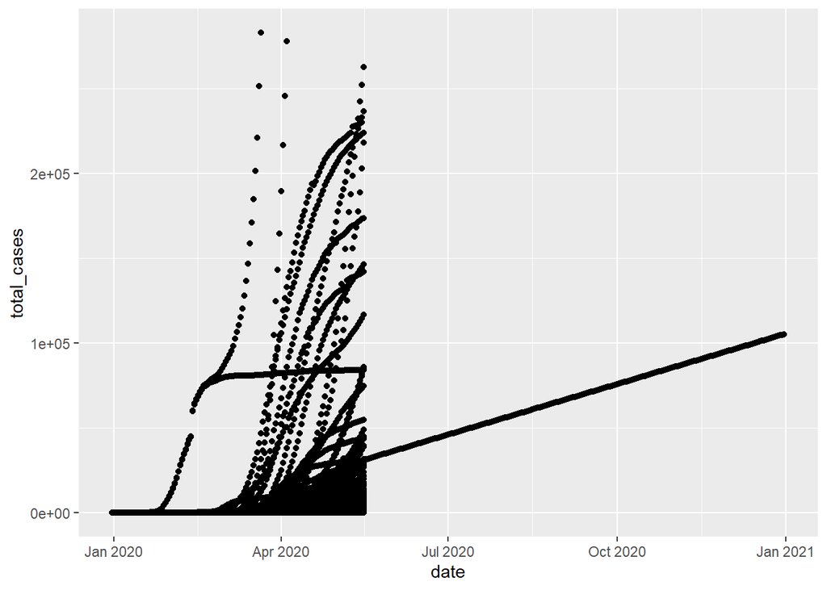

```r
new_df <- new_df %>%
  filter(total_cases < 0.3 * 10^6)

new_df %>%
  ggplot(aes(x = date, y = total_cases)) +
  geom_point()
```

There appears to be multiple logistic curves in the isolated trend from the original data with the highest density of points.